# Validación y Análisis de Calidad de Datos (DQA) - EMRS VenEsperanza

Este proyecto implementa un **flujo automatizado de validación y análisis de calidad de datos (DQA)** utilizando **R + Quarto**.  
Permite procesar archivos de datos en formato **Excel, CSV o TXT**, ejecutar un conjunto de reglas de validación y generar un **informe Word** con estadísticas, resúmenes y hallazgos.

# Requisitos del software

Sugerencia: Instala primero R, luego RStudio y finalmente Quarto.

# Proceso lógico del flujo DQA

A continuación, un esquema de los pasos que sigue el proyecto:

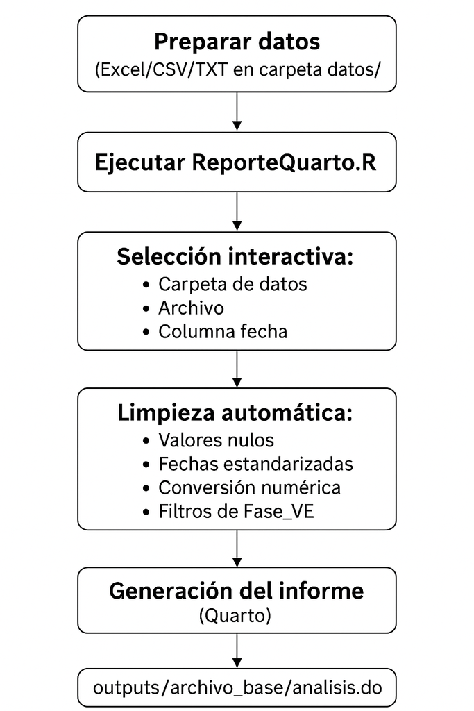

Ingresar carpeta datos

## Flujo básico de ejecución

1. **Preparar los datos**
   - Colocar los archivos en una subcarpeta dentro de `datos/`.
   - Los formatos permitidos son: `.xlsx`, `.xls`, `.csv`, `.txt`.
2. **Ejecutar el script principal**
   - Abrir R o RStudio.
   - Correr:

```r
     source("ReporteQuarto.R")
```

## Etapas detalladas del Proceso

### Etapa 1. Preparación de la data

1. Ubica la carpeta **`datos`** y localiza el archivo a analizar:

[figure not shown]

2. Selecciona el archivo a analizar:

[figure not shown]

3. Define la **columna índice** de la base de datos (ej. `caseid`, en otros casos puede ser `formid`):

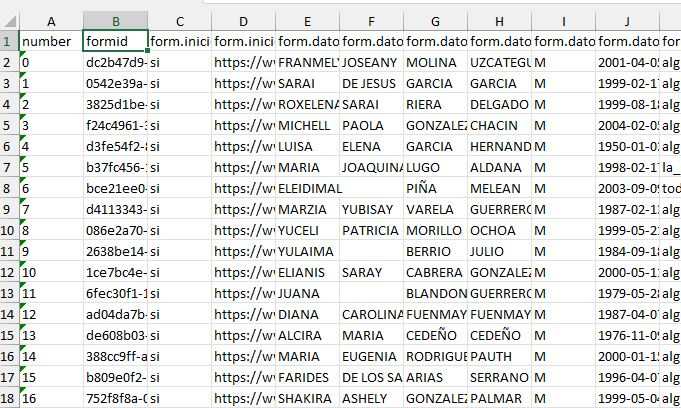

4. Selecciona la **columna de fecha** en la que fue creado el registro (ej. `open_date`, en otros casos `started_time`):

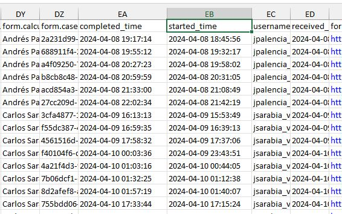

*advertencia*: Es posible que tengas algun error si las propiesdades del indice y de la fecha no existen.

### Etapa 2. Preparación y ejecución de los scripts

1. Abre **RStudio**:

[figure not shown]

2. Abre la carpeta del proyecto para ejecutar el DQA:

[figure not shown]

3. Selecciona el archivo **`ReporteQuarto.R`**:

[figure not shown]

4. Revisa los **parámetros de fecha** (ejemplo `fecha_inicio = "2024-09-01"`):

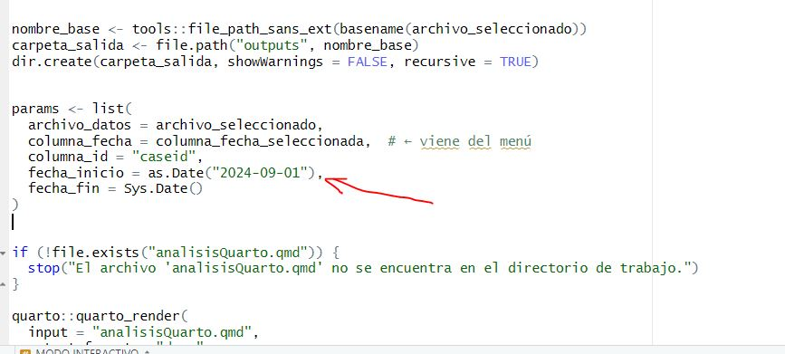

   Si quieres usar otra fecha, modifica el parámetro y guarda el archivo.
5. Ejecuta el script con `source`:

[figure not shown]

6. Selecciona la carpeta y archivo a analizar:

[figure not shown]

[figure not shown]

7. Selecciona el campo de fecha del documento:

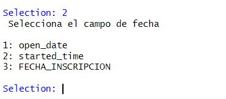

El proceso puede tardar algunos minutos dependiendo del tamaño del archivo y número de columnas:

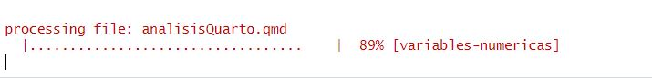

Al finalizar, deberías ver mensajes de confirmación:

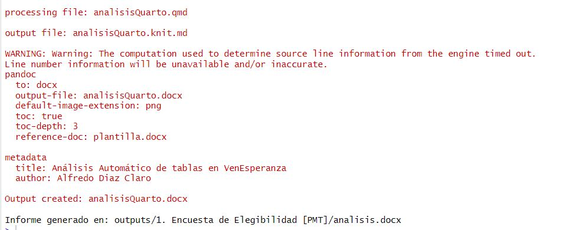

️ *Nota*: si aparecen *warnings*, no afectan la generación del informe.

### Etapa 3. Resultados e informes generados

1. Ubica la carpeta **`outputs/`**:

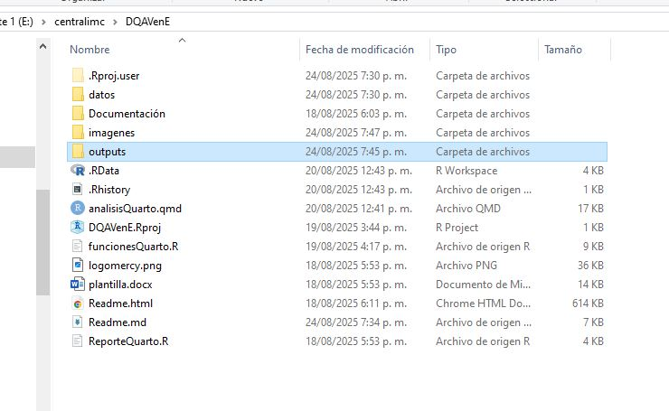

2. Dentro estará una subcarpeta con el nombre del archivo analizado. Allí encontrarás:
- **Informe Word** → `analisis.docx`
- **Archivos de apoyo (logs y datasets limpios)**

[figure not shown]

Resultados carpeta

3. Abre el archivo `analisis.docx` y revisa el índice con el DQA básico de la base cargada:

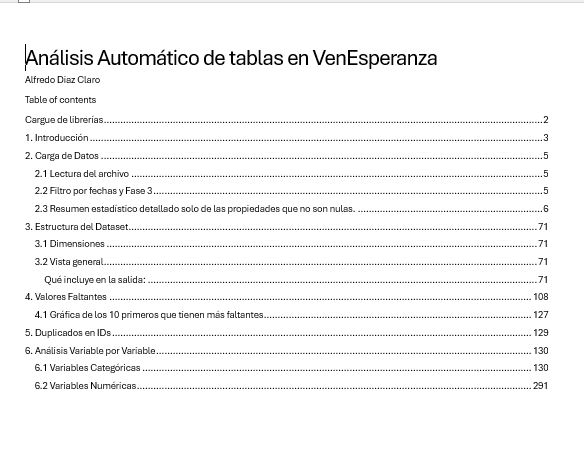

4. También puedes revisar los archivos de log y resultados de limpieza para trazabilidad:

[figure not shown]

## ️ Archivos principales

### `funcionesQuarto.R`

Contiene funciones reutilizables para: - **Lectura y estandarización** de datos (Excel/CSV/TXT). - **Conversión de fechas** a formato estándar. - **Limpieza de valores** (espacios, NA, duplicados). - **Transformaciones auxiliares** para las validaciones.

### `analisisQuarto.qmd`

Documento Quarto que genera el **informe Word**.  
Incluye: - **Estadísticas descriptivas** (conteo, NA, distribuciones). - **Exploración de variables por tipo** (numéricas, categóricas, fechas). - **Validaciones de calidad de datos** (consistencia, integridad, formatos). - **Tablas y gráficos** para resumir los hallazgos.

### `ReporteQuarto.R`

Script **controlador del flujo**: - Gestiona el directorio de trabajo. - Instala/carga paquetes necesarios. - Ofrece un **modo automático** (procesa un archivo definido sin menús). - Ofrece un **modo interactivo** (menús para elegir carpeta, archivo y columna de fecha). - Llama a `analisisQuarto.qmd` pasando parámetros (`archivo_datos`, `columna_fecha`, `columna_id`, `fecha_inicio`, `fecha_fin`). - Mueve el informe generado a la carpeta correspondiente en `outputs/`.

## Modo Automático

Si quieres evitar los menús y definir directamente el archivo a procesar:

1. Abrir `ReporteQuarto.R`.
2. Cambiar la línea:

```r
   modo_automatico <- FALSE
```

## Recomendaciones para el uso del sistema DQA

Antes de ejecutar el proceso de validación de calidad de datos (DQA), tenga en cuenta las siguientes recomendaciones:

1. **Formato de archivos**
   - Use únicamente archivos en formato **Excel (.xlsx, .xls), CSV (.csv) o TXT (.txt)**.
   - Evite formatos no soportados (ej. `.sav`, `.dta`, `.pdf`).
2. **Selección de columnas**
   - Si ya tiene definidas las variables de interés, **elimine previamente las columnas innecesarias** para mejorar la velocidad y claridad del análisis.
   - Revise que los nombres de las columnas no tengan **espacios extra o caracteres especiales**.
3. **Identificadores y campos clave**
   - Verifique que exista una columna **índice**: `caseid` o `formid`.
   - Revise que exista al menos una columna de **fecha válida** (`open_date`, `started_time`, `FECHA_INSCRIPCION`).
   - Si estos campos no están presentes, el sistema puede generar **errores de validación** o producir resultados incompletos.
4. **Rangos de fecha**
   - Confirme que sus datos contengan registros desde la **fecha de inicio** configurada.
   - Si no existen datos en ese rango, los resultados aparecerán **vacíos**.
5. **Valores faltantes**
   - Anticipe la existencia de **NA o celdas vacías**, ya que estas se incluirán en las estadísticas de calidad.
   - Si es posible, limpie previamente valores irrelevantes como `"."`, `"NA"`, `"9999"` o `"No aplica"`.
6. **Tipos de dato**
   - Asegúrese de que las columnas de **fechas** estén en formato de fecha (`yyyy-mm-dd`).
   - Las columnas numéricas (ej. edad, puntajes) deben estar en formato **numérico real** y no como texto.
7. **Nombres consistentes**
   - Mantenga los mismos nombres de variables entre archivos y subcarpetas (ejemplo: no usar `CaseID` en un archivo y `caseid` en otro).
8. **Estructura de carpetas**
   - Coloque los archivos de entrada en la carpeta **`datos/`** y, dentro de ella, en la **subcarpeta correspondiente**.
   - No modifique la carpeta `outputs/`, ya que allí se almacenan los reportes generados automáticamente.
9. **Tamaño de archivo**
   - Archivos muy pesados (ej. más de 100 MB) pueden tardar más tiempo en procesarse o generar errores de memoria. Considere dividirlos en partes.
10. **Verificación final**
    - Revise que los nombres de archivo no contengan **caracteres especiales** (`ñ, tildes, espacios, símbolos`) para evitar problemas de lectura.
    - Siempre corra el script primero con un **archivo pequeño de prueba**, para validar que los parámetros funcionan antes de usarlo en la base completa.